# bcRep: Advanced Analysis of B Cell Receptor Repertoire Data

### Clone features

Functions to analyse clone features, like CDR3 length distribution or clone copy number, are provided.

#### CDR3 length distribution of clones

Using `clones.CDR3Length()` CDR3 length distribution of clones can be estimated. The corresponding visualization method is `plotClonesCDR3Length()`. Input for both functions are vectors containing nucleotide or amino acid sequences. Further functionality and junction frame usage, depending on CDR3 length can be studied. Absolute or relative values can be returned.

```r
# Example:
data(clones.ind)
CDR3length<-clones.CDR3Length(CDR3Length = clones.ind$CDR3_length_AA,
                  functionality = clones.ind$Functionality_all_sequences)

# output of some CDR3 length proportions (CDR3length$CDR3_length[1:3]):
```

| CDR3_length_7 | CDR3_length_8 | CDR3_length_9 |
| --- | --- | --- |
| 0.018 | 0.013 | 0.007 |

```r
# output of functionality ratios for some CDR3 lengths
    # (CDR3length$CDR3_length_vs_functionality[,1:3)])
```

[output not shown]

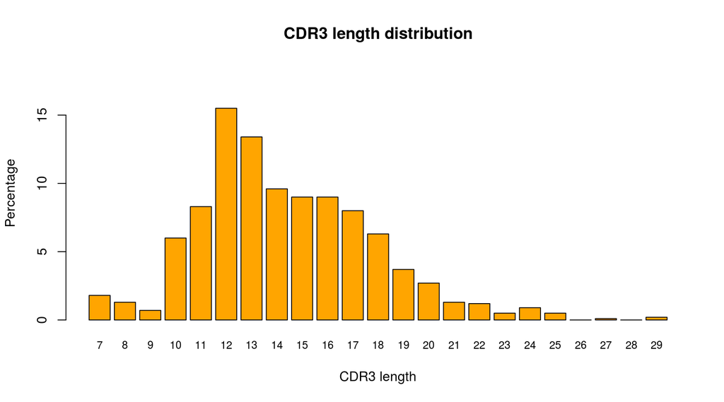

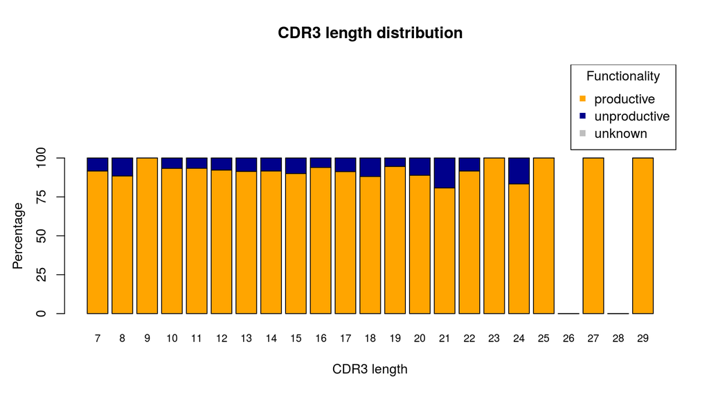

```r
plotClonesCDR3Length(CDR3Length = clones.ind$CDR3_length_AA,
                     functionality = clones.ind$Functionality_all_sequences,
                     title = "CDR3 length distribution", PDF = NULL)
```

#### Clone copy number distribution

`plotClonesCopyNumber()` can be used to plot clone sizes as an boxplot.

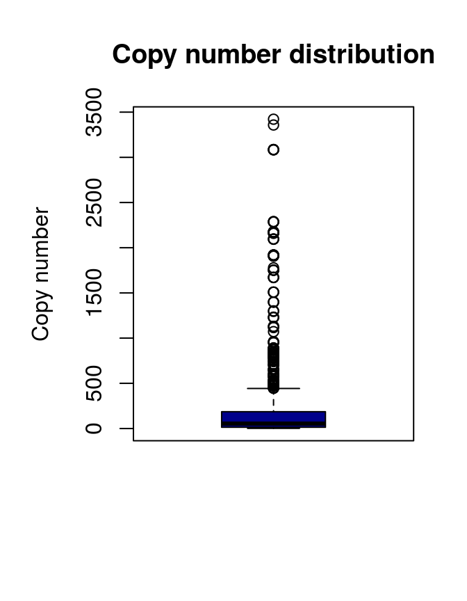

```r
# Example: Clone copy number distribution with and without outliers
plotClonesCopyNumber(copyNumber = clones.ind$total_number_of_sequences,
                     withOutliers=TRUE, color = "darkblue",
                     title = "Copy number distribution", PDF = NULL)
```

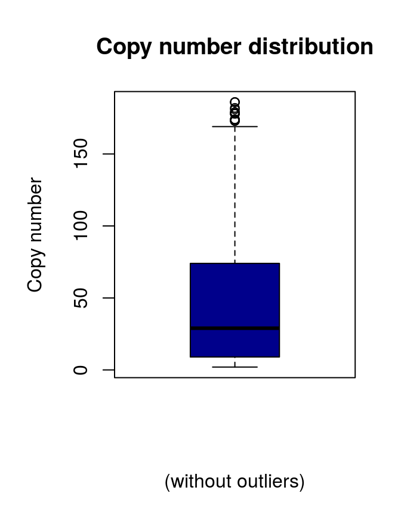

```r
plotClonesCopyNumber(copyNumber = clones.ind$total_number_of_sequences,
                     withOutliers=FALSE, color = "darkblue",
                     title = "Copy number distribution", PDF = NULL)
```

Further functions like `geneUsage()`or `trueDiversity()` can be used for further analysis of clone sets.

## Comparison of different samples

If more than one sample should be analyzed, bcRep provides some functions to compare different samples. Gene usage, amino acid distribution, diversity and shared clones can be compared and visualized.

### Comparison of gene usage

Gene usage can be compared using `compare.geneUsage()`. Input is a list including sequence vectors of each individual. If no names for the samples are specified, samples will be called Sample1, Sample2, … in input order. Analysis of subgroup (e.g. IGHV1), gene (e.g. IGHV1-1) or allele (e.g. IGHV1-1*2), as well as of relative or absolute values is possible.

Results can be visualized using `plotCompareGeneUsage()` (optional saved as PDF in working directory). A heatmap will be returned, with samples as rows and genes as columns. Proportions of genes are color coded.

```r
data(aaseqtab)
data(aaseqtab2)
V.comp<-compare.geneUsage(gene.list = list(aaseqtab$V_GENE_and_allele,
                                           aaseqtab2$V_GENE_and_allele),
                               level = "subgroup", abundance = "relative",
                          names = c("Individual1", "Individual2"),
                          nrCores = 1)
```

|  | IGHV1 | IGHV2 | IGHV3 | IGHV4 | IGHV5 | IGHV6 | IGHV7 |
| --- | --- | --- | --- | --- | --- | --- | --- |
| **Individual1** | 0.1675 | 0.002404 | 0.6305 | 0.1687 | 0.02164 | 0.007213 | 0.002004 |
| **Individual2** | 0.1242 | 0.004302 | 0.6834 | 0.154 | 0.0222 | 0.007228 | 0.004646 |

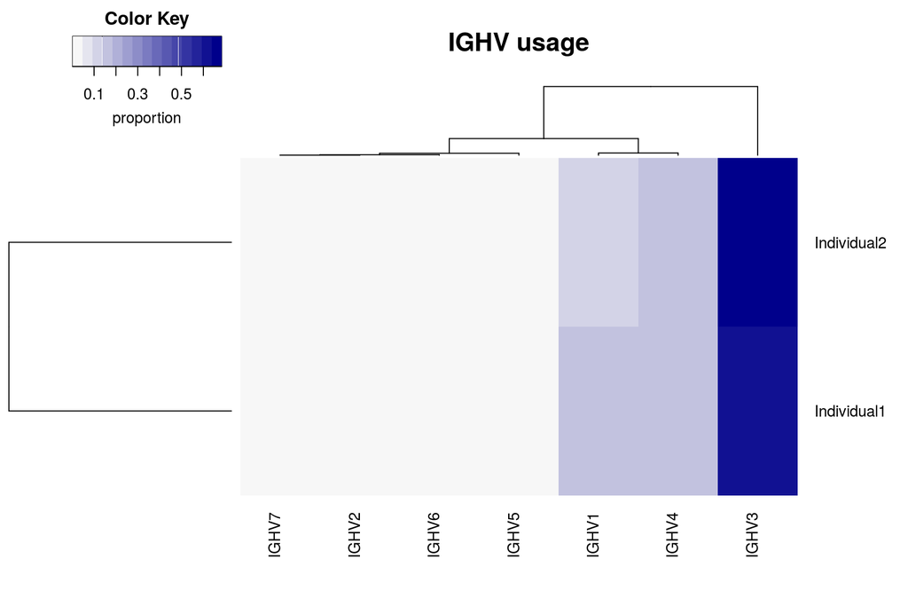

```r
plotCompareGeneUsage(comp.tab = V.comp, color = c("gray97", "darkblue"), PDF = NULL)
```

### Comparison of amino acid distribution

The amino acid distribution between two or more individuals can be compared using `compare.aaDistribution()`. Input is a list including sequence vectors for each individual. Sequences of the same length will be analyzed together. Optional the number of sequences used for analysis can be returned. If no names for the samples are specified, samples will be called Sample1, Sample2, … in input order.

The output is a list, containing amino acid distributions for each sequence length and each individual.

`plotCompareAADistribution()` returns a plot (optional saved as PDF in working directory), where columns represent the samples, and rows represent different sequence lengths. In each field, one bar represents one position of the sequence.

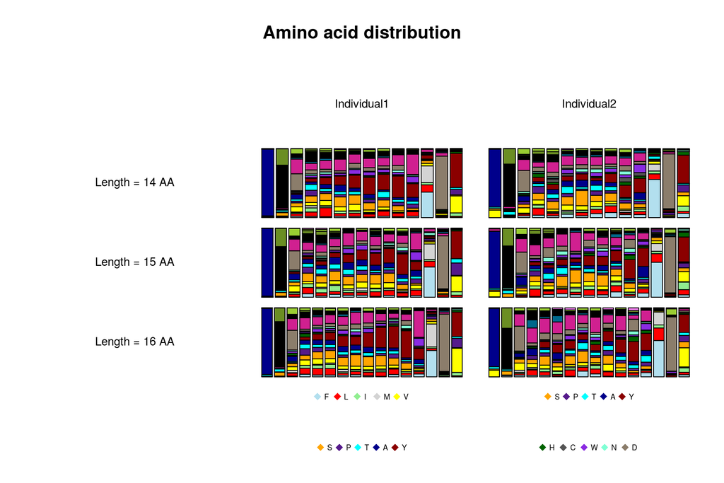

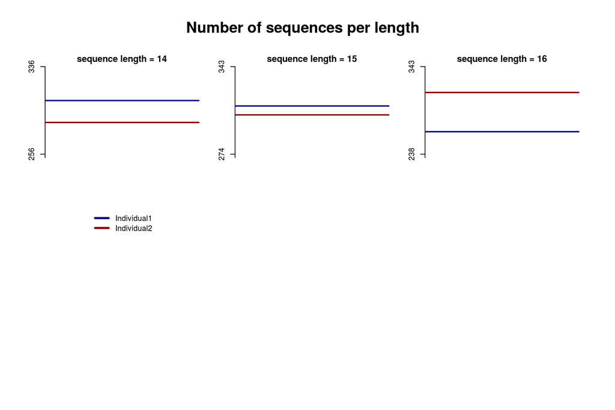

```r
data(aaseqtab)
data(aaseqtab2)
AAdistr.comp<-compare.aaDistribution(sequence.list = list(aaseqtab$CDR3_IMGT,
                                                          aaseqtab2$CDR3_IMGT),
                                     names = c("Individual1", "Individual2"),
                                     numberSeq = TRUE, nrCores = 1)

# Comparison of sequence length of 14-16 amino acids:
## Individual 1: grep("14|15|16",names(AAdistr.comp$Amino_acid_distribution$Individual1))
        ## >> 13:15
## Individual 2: grep("14|15|16",names(AAdistr.comp$Amino_acid_distribution$Individual2))
        ## >> 12:14
AAdistr.comp.part<-list(list(AAdistr.comp$Amino_acid_distribution$Individual1[13:15],
                             AAdistr.comp$Amino_acid_distribution$Individual2[12:14]),
                        list(AAdistr.comp$Number_of_sequences_per_length$Individual1[13:15],
                             AAdistr.comp$Number_of_sequences_per_length$Individual2[12:14]))
names(AAdistr.comp.part)<-names(AAdistr.comp)
names(AAdistr.comp.part$Amino_acid_distribution)<-
  names(AAdistr.comp$Amino_acid_distribution)
names(AAdistr.comp.part$Number_of_sequences_per_length)<-
  names(AAdistr.comp$Number_of_sequences_per_length)

plotCompareAADistribution(comp.tab = AAdistr.comp.part, plotSeqN = TRUE,
                          colors=c("darkblue","darkred"), PDF = NULL)
```

### Comparison of richness and diversity

Richness and diversity can be compared using `compare.trueDiversity()`. Input can be a list of sequences or the output of `compare.aaDistribution()`. Diversity can be analyzed for order 0 (richness), 1 (exponent of Shannon entropy) or 2 (inverse Simpson) (see diversity analysis above). If no names for the samples are specified, samples will be called Sample1, Sample2, … in the input order.

The output is a list, containing richness or diversity indices for each sequence length and each individual.

Results can be visualized using `plotCompareTrueDiversity()` (optional saved as PDF in working directory). A plot will be returned, with one figure for each sequence length, if `mean.plot = F`. If `mean.plot = T` only one figure with mean diversity values for all sequences with the same length will be returned. Each figure contains the sequence position on the x-axis and the richness/diversity index on the y-axis. If no colors are specified, `rainbow()` will be used.

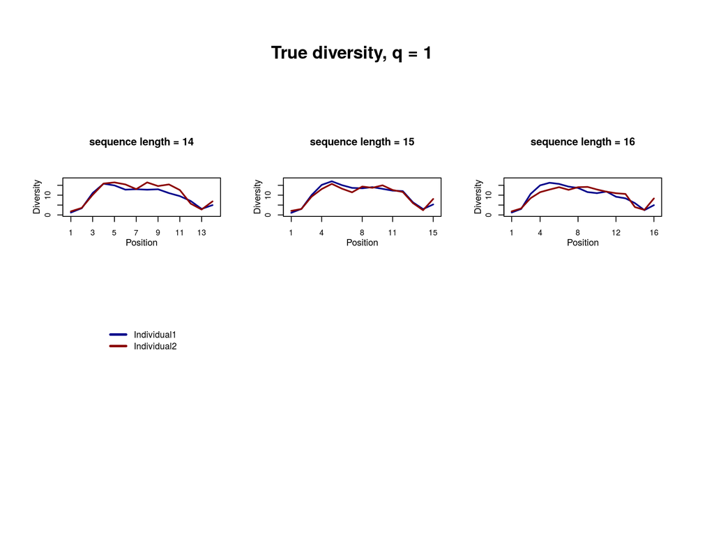

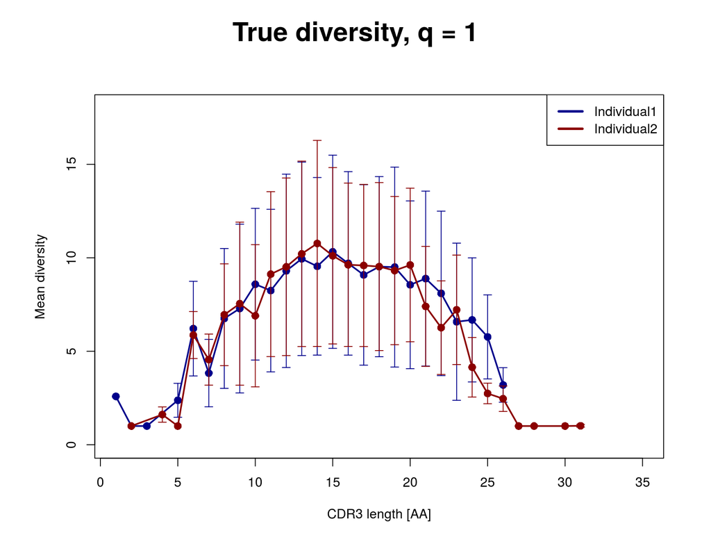

```r
data(aaseqtab)
data(aaseqtab2)
trueDiv.comp<-compare.trueDiversity(sequence.list = list(aaseqtab$CDR3_IMGT,
                                                         aaseqtab2$CDR3_IMGT),
                                    names = c("Individual1", "Individual2"),
                                    order = 1, nrCores = 1)

# Comparison of sequence length of 14-16 amino acids:
grepindex1<-grep("14|15|16",names(trueDiv.comp$Individual1))
grepindex2<-grep("14|15|16",names(trueDiv.comp$Individual2))
trueDiv.comp.part<-list(trueDiv.comp$True_diversity_order,
                        trueDiv.comp$Individual1[grepindex1],
                        trueDiv.comp$Individual2[grepindex2])
names(trueDiv.comp.part)<-names(trueDiv.comp)
plotCompareTrueDiversity(comp.tab = trueDiv.comp.part, mean.plot = F, colors=c("darkblue","darkred"),
                         PDF = NULL)
plotCompareTrueDiversity(comp.tab = trueDiv.comp, mean.plot = T, colors = c("darkblue","darkred"),
                         PDF = NULL)
```